# Aviation Facility Sampling and Inference

# Inferential Statistics

## Two-sample difference of mean test

**Q9** Does the mean elevation differ between AIRPORT and HELIPORT facilities? Write the null hypothesis and alternate hypothesis?

The null hypothesis (H₀) states that there is no difference in the mean elevation between airport and heliport facilities.

H₀: μ_airport = μ_heliport

The alternative hypothesis (H₁) states that the mean elevation differs between airport and heliport facilities.

H₁: μ_airport ≠ μ_heliport

**Q10** What would happen if you used a parametric difference of mean test on non-parametric data?

If a parametric mean difference test is applied to nonparametric data, the test’s assumptions will be violated. In this case, the statistical results may become unreliable or misleading. For example, it may fail to detect truly existing differences or detect false differences. In such situations, a nonparametric test is more appropriate.

**Q11** Please select an appropriate statistical test, and provide justifications by visualizing the distribution, using the stratified sample subset.

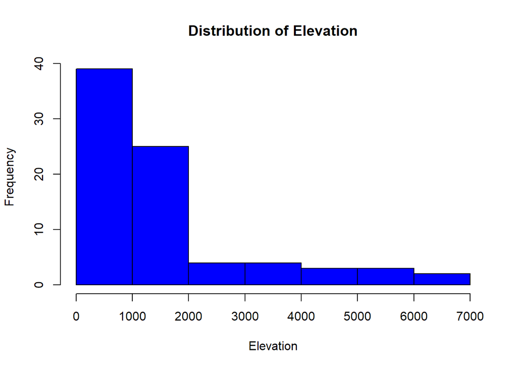

```r
# ToDo
hist(stratified_sample$ELEV, main = "Distribution of Elevation", xlab = "Elevation", col = "blue")
```

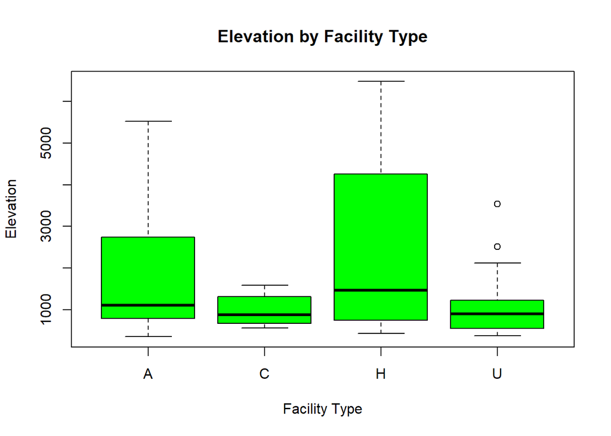

```r
boxplot(ELEV ~ SITE_TYPE_CODE, data = stratified_sample, main = "Elevation by Facility Type", xlab = "Facility Type", ylab = "Elevation", col = "green")
```

The two graphs show that the distribution is skewed and does not conform to a normal distribution, then the non-parametric test more appropriate. Therefore, we choose the Wilcoxon rank-sum test to compare the average altitude of airport and heliport facilities.

(6 marks) **Q12** Please conduct the statistic test and interpret the results. Create 2 vectors (airport and heliport), each containing elevation values from each facility type. Then use a non-parametric difference of means test.

```r
#TODO (2 marks)
airport <- stratified_sample$ELEV[stratified_sample$SITE_TYPE_CODE == "A"] heliport <- stratified_sample$ELEV[stratified_sample$SITE_TYPE_CODE == "H"] wilcox.test(airport, heliport)
```

```
## ## Wilcoxon rank sum exact test
## ## data: airport and heliport
## W = 176, p-value = 0.5291
## alternative hypothesis: true location shift is not equal to 0
```

**Type the statistic results and interpretation here** The test results showed that the statistic W = 176 and the p-value was 0.5291. Since the p-value was greater than the significance level of 0.05, we could not reject the null hypothesis. There was no statistically significant difference in altitude between the airport and heliport facilities.

## Three-sample Mean Difference Test

(8 marks) **Q13** Please follow the same procedure above to test whether the 1st quartile elevation differs between facility types.

: Box plots show the elevation distribution of the airport (A), heliport (H), and seaplane base (C), with significant differences in elevation among these three facility types. ANOVA results showed an F-value of 29.77 and a p-value of 1.29e-13. Since the p-value was much smaller than the significance level of 0.05, we rejected the null hypothesis. This indicates a statistically significant difference in elevation among these three facility types.

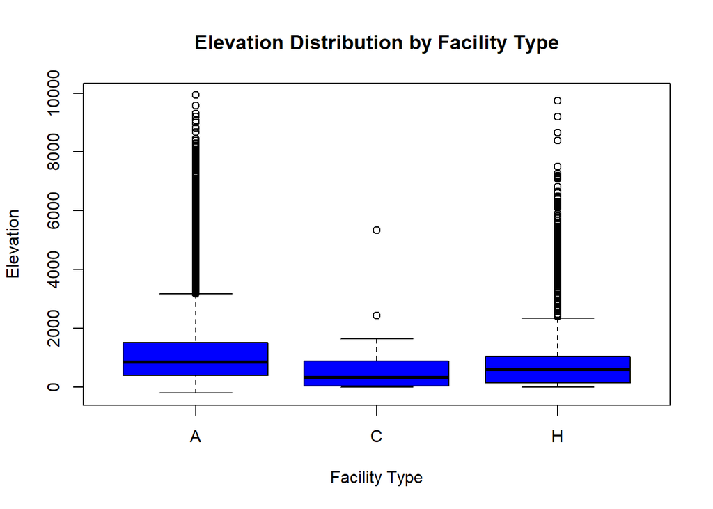

```r
#ToDo
# Visualize Distribution (1 mark)
boxplot(ELEV ~ SITE_TYPE_CODE, data = subset(filtered_states, SITE_TYPE_CODE %in% c("A","H","C")), main = "Elevation Distribution by Facility Type", xlab = "Facility Type", ylab = "Elevation", col = "blue")
```

```r
#ToDo
# ANOVA Test using the filtered dataset (A/H/C)
ahc_data <- subset(filtered_states, SITE_TYPE_CODE %in% c("A","H","C"))
anova_test <- aov(ELEV ~ SITE_TYPE_CODE, data = ahc_data) summary(anova_test)
```

```
## Df Sum Sq Mean Sq F value Pr(>F) ## SITE_TYPE_CODE 2 1.474e+08 73705960 29.77 1.29e-13 ***
## Residuals 9250 2.290e+10 2475549 ## ---
## Signif. codes: 0 '***' 0.001 '**' 0.01 '*' 0.05 '.' 0.1 ' ' 1
```

#Type 1 and Type 2 error **Q14** Discuss what the Type 1 and Type 2 errors would be for both your 2-sample and 3-sample difference of means tests. Why is it important to understand Type 1 and Type 2 errors?

Type I errors occur when the null hypothesis is actually true, but is incorrectly rejected. In a two-sample test, this might lead to the conclusion that airport and heliport facilities have different average altitudes when there is actually no difference. In a three-sample test, it might lead to the conclusion that at least one facility type has a different average altitude when all facility types have the same average altitude.

Type II errors occur when the null hypothesis is false, but is not incorrectly rejected. In a two-sample test, this might lead to the conclusion that airport and heliport facilities have no difference in altitude when there is. In a three-sample test, it might fail to detect the true differences in altitude between different facility types.

Understanding Type I and Type II errors is crucial. Recognizing these errors helps assess the reliability of conclusions and understand the risks of making incorrect decisions based on statistical results.